# 重賞レース予測レポート【レース終了】

作成日時: 2026/10/04 16:44:22

☞ [マニュアル(pdf)](https://ryutoro-galois.github.io/keiba-predictor/manual/manual.pdf)

☞ 過去6年の同一レース結果: [2025年](https://ryutoro-galois.github.io/keiba-predictor/report/PredResult_2025y_raceDate_20251005_20251005.html), [2024年](https://ryutoro-galois.github.io/keiba-predictor/report/PredResult_2024y_raceDate_20241005_20241006.html), [2023年](https://ryutoro-galois.github.io/keiba-predictor/report/PredResult_2023y_raceDate_20231007_20231009.html), [2022年](https://ryutoro-galois.github.io/keiba-predictor/report/PredResult_2022y_raceDate_20221008_20221010.html), [2021年](https://ryutoro-galois.github.io/keiba-predictor/report/PredResult_2021y_raceDate_20211009_20211010.html), [2020年](https://ryutoro-galois.github.io/keiba-predictor/report/PredResult_2020y_raceDate_20201010_20201011.html)

☞ 過去4週間の別レース結果: [1週前(9/26-27)](https://ryutoro-galois.github.io/keiba-predictor/report/PredResult_2026y_raceDate_20260926_20260927.html), [2週前(9/19-21)](https://ryutoro-galois.github.io/keiba-predictor/report/PredResult_2026y_raceDate_20260919_20260921.html), [3週前(9/12-13)](https://ryutoro-galois.github.io/keiba-predictor/report/PredResult_2026y_raceDate_20260912_20260913.html), [4週前(9/5-6)](https://ryutoro-galois.github.io/keiba-predictor/report/PredResult_2026y_raceDate_20260905_20260906.html)

☞ netkeiba: [毎日王冠(GⅡ)](https://race.netkeiba.com/race/result.html?race_id=202605040211&rf=race_submenu), [京都大賞典(GⅡ)](https://race.netkeiba.com/race/result.html?race_id=202608040211&rf=race_submenu)

☞ レース結果(csv): [10/3-4](https://ryutoro-galois.github.io/keiba-predictor/csv/race_result_20261003_20261004.csv)

## 【レース結果(1)】人気と着順の関係

### 【毎日王冠(2026/10/04(日))】

【毎日王冠(GⅡ)】  
2026/10/04(日), 05_東京, 芝左1800m

[interactive chart not shown]

### 【京都大賞典(2026/10/04(日))】

【京都大賞典(GⅡ)】  
2026/10/04(日), 08_京都, 芝右外2400m

[interactive chart not shown]

## 【レース結果(2)】コーナー通過順位

### 【毎日王冠(2026/10/04(日))】

【毎日王冠(GⅡ)】  
2026/10/04(日), 05_東京, 芝左1800m

[interactive chart not shown]

### 【京都大賞典(2026/10/04(日))】

【京都大賞典(GⅡ)】  
2026/10/04(日), 08_京都, 芝右外2400m

[interactive chart not shown]

## 0. 推し馬予測 (AI予測)

### 【毎日王冠(GⅡ) 2026/10/04(日)】

- 本命(◎): 1-3着内確率(勝負強さ)が1位の馬
- 対抗(◯): 1-3着内確率が2-N位(20%程度以上)の中で予測タイムが最も速い馬
- 3番手(▲): 1-3着内確率が2-N位(20%程度以上)のでダークホース確率が最も高い馬
- 穴: ダークホース確率が上位1-M位(40%程度以上)の中で1-3着内確率が最も高い馬

| 推し馬 | 枠番 | 馬番 | 人気 | オッズ | 馬名 | 騎手 | 調教師 | 予測タイム(sec) | 1_順位 | 1-3着内確率(%) | 2_順位 | ﾀﾞｰｸﾎｰｽ確率(%) | 3_順位 |
| --- | --- | --- | --- | --- | --- | --- | --- | --- | --- | --- | --- | --- | --- |
| 本命(◎) | 3 | 6 | 2 | 3.8 | ライヒスアドラー | 佐々木大輔 | 上原佑紀 | 105.3 | 7 | 50.3 | 1 | 0.5 | 15 |
| 対抗(◯) | 2 | 3 | 7 | 19.6 | レディネス | 横山典弘 | 昆貢 | 104.5 | 3 | 20.6 | 6 | 1.2 | 9 |
| 3番手(▲) | 8 | 17 | 12 | 47.1 | ダノンエアズロック | 田辺裕信 | 堀宣行 | 108.5 | 8 | 31.5 | 4 | 50.3 | 1 |
| 穴 | 3 | 5 | 15 | 225.9 | クルゼイロドスル | 荻野極 | 高橋義忠 | 112.9 | 10 | 8.3 | 12 | 48.4 | 2 |

### 【京都大賞典(GⅡ) 2026/10/04(日)】

- 本命(◎): 1-3着内確率(勝負強さ)が1位の馬
- 対抗(◯): 1-3着内確率が2-N位(20%程度以上)の中で予測タイムが最も速い馬
- 3番手(▲): 1-3着内確率が2-N位(20%程度以上)のでダークホース確率が最も高い馬
- 穴: ダークホース確率が上位1-M位(40%程度以上)の中で1-3着内確率が最も高い馬

| 推し馬 | 枠番 | 馬番 | 人気 | オッズ | 馬名 | 騎手 | 調教師 | 予測タイム(sec) | 1_順位 | 1-3着内確率(%) | 2_順位 | ﾀﾞｰｸﾎｰｽ確率(%) | 3_順位 |
| --- | --- | --- | --- | --- | --- | --- | --- | --- | --- | --- | --- | --- | --- |
| 本命(◎) | 2 | 3 | 3 | 5.6 | ディープモンスター | 浜中俊 | 池江泰寿 | 148.6 | 6.0 | 42.4 | 1 | 0.4 | 18 |
| 対抗(◯) | 3 | 6 | 2 | 5.5 | アクアヴァーナル | 松山弘平 | 四位洋文 | 142.9 | 1.5 | 21.7 | 4 | 0.5 | 15 |
| 3番手(▲) | 2 | 4 | 5 | 8.8 | ヘデントール | 吉田隼人 | 木村哲也 | 146.0 | 4.0 | 34.7 | 2 | 0.6 | 13 |
| 穴 | 8 | 17 | 12 | 30.3 | キングスコール | 吉田豊 | 矢作芳人 | 146.3 | 5.0 | 16.9 | 6 | 63.0 | 4 |

## 1. 予測チャート (タイム/勝負強さ)

### 【毎日王冠(GⅡ)】

2026/10/04(日), 05_東京, 芝左1800m

[interactive chart not shown]

### 【京都大賞典(GⅡ)】

2026/10/04(日), 08_京都, 芝右外2400m

[interactive chart not shown]

## 2. オッズモニタリング (毎時)

### 【毎日王冠】

[interactive chart not shown]

### 【京都大賞典】

[interactive chart not shown]

## 3. 出馬表

### 【毎日王冠 2026/10/04(日) 】

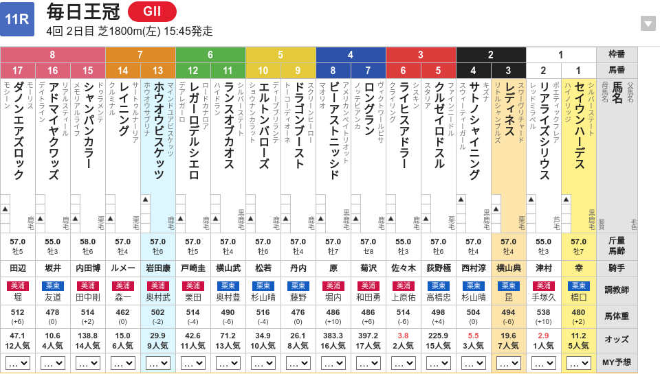

### 【京都大賞典 2026/10/04(日) 】

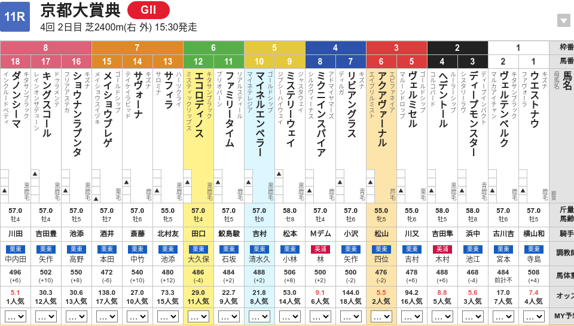

## 4. 単勝予測結果

### 【毎日王冠(GⅡ) 2026/10/04(日)】

| 枠番 | 馬番 | 人気 | オッズ | 馬名 | 騎手 | 調教師 | 予測タイム(sec) | 1_順位 | 1-3着内確率(%) | 2_順位 | ﾀﾞｰｸﾎｰｽ確率(%) | 3_順位 |
| --- | --- | --- | --- | --- | --- | --- | --- | --- | --- | --- | --- | --- |
| 1 | 1 | 5 | 11.2 | セイウンハーデス | 幸英明 | 橋口慎介 | 115.2 | 15 | 17.6 | 9 | 1.0 | 10 |
| 1 | 2 | 1 | 2.9 | リアライズシリウス | 津村明秀 | 手塚貴久 | 104.5 | 3 | 18.4 | 8 | 0.5 | 16 |
| 2 | 3 | 7 | 19.6 | レディネス | 横山典弘 | 昆貢 | 104.5 | 3 | 20.6 | 6 | 1.2 | 9 |
| 2 | 4 | 3 | 5.5 | サトノシャイニング | 西村淳也 | 杉山晴紀 | 104.5 | 3 | 44.5 | 2 | 0.5 | 17 |
| 3 | 5 | 15 | 225.9 | クルゼイロドスル | 荻野極 | 高橋義忠 | 112.9 | 10 | 8.3 | 12 | 48.4 | 2 |
| 3 | 6 | 2 | 3.8 | ライヒスアドラー | 佐々木大輔 | 上原佑紀 | 105.3 | 7 | 50.3 | 1 | 0.5 | 15 |
| 4 | 7 | 17 | 397.2 | ロングラン | 菊沢一樹 | 和田勇介 | 113.9 | 12 | 3.4 | 17 | 16.8 | 8 |
| 4 | 8 | 16 | 383.3 | ビーアストニッシド | 原優介 | 堀内岳志 | 115.4 | 16 | 3.7 | 16 | 30.6 | 5 |
| 5 | 9 | 8 | 26.1 | ドラゴンブースト | 丹内祐次 | 藤野健太 | 112.4 | 9 | 6.7 | 14 | 0.8 | 13 |
| 5 | 10 | 10 | 34.9 | エルトンバローズ | 松若風馬 | 杉山晴紀 | 113.0 | 11 | 10.9 | 11 | 25.6 | 6 |

[output cut: 7 more lines]

### 【京都大賞典(GⅡ) 2026/10/04(日)】

| 枠番 | 馬番 | 人気 | オッズ | 馬名 | 騎手 | 調教師 | 予測タイム(sec) | 1_順位 | 1-3着内確率(%) | 2_順位 | ﾀﾞｰｸﾎｰｽ確率(%) | 3_順位 |
| --- | --- | --- | --- | --- | --- | --- | --- | --- | --- | --- | --- | --- |
| 1 | 1 | 4 | 7.4 | ウエストナウ | 横山和生 | 寺島良 | 152.3 | 10.0 | 24.7 | 3 | 0.4 | 17 |
| 1 | 2 | 7 | 17.0 | ヴェルテンベルク | 古川吉洋 | 宮本博 | 153.6 | 17.0 | 12.1 | 9 | 2.1 | 10 |
| 2 | 3 | 3 | 5.6 | ディープモンスター | 浜中俊 | 池江泰寿 | 148.6 | 6.0 | 42.4 | 1 | 0.4 | 18 |
| 2 | 4 | 5 | 8.8 | ヘデントール | 吉田隼人 | 木村哲也 | 146.0 | 4.0 | 34.7 | 2 | 0.6 | 13 |
| 3 | 5 | 16 | 94.2 | ヴェルミセル | 川又賢治 | 吉村圭司 | 152.2 | 9.0 | 9.2 | 11 | 64.6 | 3 |
| 3 | 6 | 2 | 5.5 | アクアヴァーナル | 松山弘平 | 四位洋文 | 142.9 | 1.5 | 21.7 | 4 | 0.5 | 15 |
| 4 | 7 | 18 | 144.0 | リビアングラス | 小沢大仁 | 矢作芳人 | 152.6 | 15.0 | 4.1 | 16 | 67.4 | 2 |
| 4 | 8 | 6 | 9.1 | ミクニインスパイア | Ｍ．デムーロ | 林徹 | 152.3 | 12.0 | 14.4 | 8 | 0.5 | 14 |
| 5 | 9 | 14 | 53.0 | ミステリーウェイ | 松本大輝 | 小林真也 | 151.9 | 8.0 | 2.4 | 18 | 16.2 | 8 |
| 5 | 10 | 8 | 21.8 | マイネルエンペラー | 吉村誠之助 | 清水久詞 | 144.7 | 3.0 | 15.8 | 7 | 1.3 | 11 |

[output cut: 8 more lines]

## 5. 人気と着順の乖離率推移

### 【毎日王冠_1990y_2019y】

[interactive chart not shown]

### 【京都大賞典_1990y_2019y】

[interactive chart not shown]

### 【毎日王冠_1990y_2019y】

| No | 開催年 | 不整合率(%) | 頭数 | 人気別着順(1-3位) | 人気別着順(全体) |
| --- | --- | --- | --- | --- | --- |
| 30 | 2019 | 2.4 | 10頭 | 1-2-3 | 1\|2\|3\|4\|8\|5\|6\|10\|7\|9 |
| 29 | 2018 | 28.2 | 13頭 | 1-3-6 | 1\|3\|6\|8\|4\|2\|5\|11\|10\|7\|13\|9\|12 |
| 28 | 2017 | 66.9 | 12頭 | 3-5-4 | 3\|5\|4\|7\|8\|2\|10\|1\|11\|9\|6\|12 |
| 27 | 2016 | 18.9 | 12頭 | 1-3-11 | 1\|3\|11\|12\|2\|4\|6\|5\|10\|9\|7\|8 |
| 26 | 2015 | 25.0 | 13頭 | 1-4-7 | 1\|4\|7\|10\|11\|2\|6\|9\|3\|5\|8\|12\|13 |
| 25 | 2014 | 62.1 | 15頭 | 8-11-5 | 8\|11\|5\|7\|2\|6\|3\|14\|12\|15\|10\|4\|1\|9\|13 |
| 24 | 2013 | 66.6 | 11頭 | 4-6-5 | 4\|6\|5\|7\|3\|1\|2\|10\|9\|8\|11 |
| 23 | 2012 | 32.4 | 16頭 | 1-12-9 | 1\|12\|9\|7\|6\|14\|5\|13\|2\|15\|3\|10\|11\|8\|16\|4 |
| 22 | 2011 | 19.5 | 11頭 | 1-2-5 | 1\|2\|5\|10\|9\|4\|7\|3\|8\|6\|11 |
| 21 | 2010 | 57.1 | 10頭 | 6-8-9 | 6\|8\|9\|3\|1\|7\|4\|5\|2\|10 |

[output cut: 20 more lines]

### 【京都大賞典_1990y_2019y】

| No | 開催年 | 不整合率(%) | 頭数 | 人気別着順(1-3位) | 人気別着順(全体) |
| --- | --- | --- | --- | --- | --- |
| 30 | 2019 | 53.6 | 16頭 | 11-6-5 | 11\|6\|5\|4\|2\|1\|7\|14\|8\|10\|15\|3\|16\|12\|9\|13 |
| 29 | 2018 | 42.3 | 11頭 | 2-4-3 | 2\|4\|3\|1\|7\|5\|10\|6\|9\|11\|8 |
| 28 | 2017 | 46.8 | 15頭 | 4-6-1 | 4\|6\|1\|3\|14\|10\|11\|9\|7\|5\|13\|15\|2\|12\|8 |
| 27 | 2016 | 14.4 | 10頭 | 1-6-2 | 1\|6\|2\|3\|7\|10\|5\|4\|9\|8 |
| 26 | 2015 | 9.7 | 10頭 | 1-2-5 | 1\|2\|5\|3\|7\|4\|8\|6\|9\|10 |
| 25 | 2014 | 48.0 | 12頭 | 3-6-1 | 3\|6\|1\|4\|9\|10\|7\|5\|11\|2\|8\|12 |
| 24 | 2013 | 37.5 | 13頭 | 11-7-2 | 11\|7\|2\|5\|1\|6\|9\|3\|12\|10\|4\|8\|13 |
| 23 | 2012 | 36.0 | 13頭 | 5-7-2 | 5\|7\|2\|1\|10\|3\|11\|6\|4\|9\|13\|12\|8 |
| 22 | 2011 | 33.5 | 8頭 | 1-4-3 | 1\|4\|3\|2\|7\|6\|5\|8 |
| 21 | 2010 | 26.3 | 10頭 | 2-1-4 | 2\|1\|4\|5\|9\|3\|10\|6\|8\|7 |

[output cut: 20 more lines]

## 6. 1-3番人気馬の着順分類予測

### 【毎日王冠】

| 分類 | 凡例 | 発生確率(%) | 当該レース | 当該レースランク | 直近1年間 |
| --- | --- | --- | --- | --- | --- |
| 4: 1,2番人気のみ (4_pop12) | 1 \| 2 \| * | 18.3 | 1.65 | 1.01 | 0.00 |
| 1: 1番人気のみ (1_pop1) | 1 \| * \| * | 18.2 | 1.31 | 1.64 | 0.00 |
| 5: 1,3番人気のみ (5_pop13) | 1 \| 3 \| * | 13.7 | 0.82 | 0.82 | 0.00 |
| 8: 1,2,3番人気すべて着外 (8_darkhorse) | * \| * \| * | 13.5 | 0.70 | 0.57 | 0.27 |
| 2: 2番人気のみ (2_pop2) | 2 \| * \| * | 9.6 | 3.43 | 1.71 | 0.00 |
| 7: 1,2,3番人気すべて着内 (7_pop123) | 1 \| 2 \| 3 | 9.5 | 0.43 | 0.76 | 0.19 |
| 6: 2,3番人気のみ (6_pop23) | 2 \| 3 \| * | 8.7 | 1.55 | 1.26 | 0.00 |
| 3: 3番人気のみ (3_pop3) | 3 \| * \| * | 8.5 | 1.02 | 1.52 | 0.00 |

### 【京都大賞典】

| 分類 | 凡例 | 発生確率(%) | 当該レース | 当該レースランク | 直近1年間 |
| --- | --- | --- | --- | --- | --- |
| 8: 1,2,3番人気すべて着外 (8_darkhorse) | * \| * \| * | 18.2 | 0.65 | 0.77 | 0.36 |
| 1: 1番人気のみ (1_pop1) | 1 \| * \| * | 17.6 | 2.12 | 1.59 | 0.00 |
| 4: 1,2番人気のみ (4_pop12) | 1 \| 2 \| * | 17.6 | 0.70 | 0.97 | 0.00 |
| 5: 1,3番人気のみ (5_pop13) | 1 \| 3 \| * | 13.5 | 0.81 | 0.81 | 0.00 |
| 2: 2番人気のみ (2_pop2) | 2 \| * \| * | 9.3 | 1.12 | 1.66 | 0.00 |
| 6: 2,3番人気のみ (6_pop23) | 2 \| 3 \| * | 8.5 | 1.02 | 1.23 | 0.00 |
| 3: 3番人気のみ (3_pop3) | 3 \| * \| * | 8.3 | 2.96 | 1.48 | 0.00 |
| 7: 1,2,3番人気すべて着内 (7_pop123) | 1 \| 2 \| 3 | 7.0 | 2.50 | 0.56 | 0.14 |

## 7. 3連複予測結果

### 【毎日王冠(GⅡ) 2026/10/04(日)】

| 分類 | 馬番 | 枠番 | 人気 | 平均予測タイム(sec) | 1-3着内確率(%) | ﾀﾞｰｸﾎｰｽ確率(%) | 馬名 | 騎手 | 調教師 |
| --- | --- | --- | --- | --- | --- | --- | --- | --- | --- |
| 6: 2,3番人気のみ (6_pop23) | 6-4-16 | 3-2-8 | 2-3-4 | 104.77 | 8.12 | 0.00 | ライヒスアドラー \| サトノシャイニング \| アドマイヤクワッズ | 佐々木大輔 \| 西村淳也 \| 坂井瑠星 | 上原佑紀 \| 杉山晴紀 \| 友道康夫 |
| 6: 2,3番人気のみ (6_pop23) | 6-4-17 | 3-2-8 | 2-3-12 | 106.10 | 7.05 | 0.00 | ライヒスアドラー \| サトノシャイニング \| ダノンエアズロック | 佐々木大輔 \| 西村淳也 \| 田辺裕信 | 上原佑紀 \| 杉山晴紀 \| 堀宣行 |
| 2: 2番人気のみ (2_pop2) | 6-16-17 | 3-8-8 | 2-4-12 | 106.10 | 5.76 | 0.00 | ライヒスアドラー \| アドマイヤクワッズ \| ダノンエアズロック | 佐々木大輔 \| 坂井瑠星 \| 田辺裕信 | 上原佑紀 \| 友道康夫 \| 堀宣行 |
| 6: 2,3番人気のみ (6_pop23) | 6-4-14 | 3-2-7 | 2-3-6 | 108.23 | 5.50 | 0.00 | ライヒスアドラー \| サトノシャイニング \| レイニング | 佐々木大輔 \| 西村淳也 \| Ｃ．ルメール | 上原佑紀 \| 杉山晴紀 \| 森一誠 |
| 3: 3番人気のみ (3_pop3) | 4-16-17 | 2-8-8 | 3-4-12 | 105.83 | 5.09 | 0.00 | サトノシャイニング \| アドマイヤクワッズ \| ダノンエアズロック | 西村淳也 \| 坂井瑠星 \| 田辺裕信 | 杉山晴紀 \| 友道康夫 \| 堀宣行 |
| 6: 2,3番人気のみ (6_pop23) | 6-4-3 | 3-2-2 | 2-3-7 | 104.77 | 4.60 | 0.00 | ライヒスアドラー \| サトノシャイニング \| レディネス | 佐々木大輔 \| 西村淳也 \| 横山典弘 | 上原佑紀 \| 杉山晴紀 \| 昆貢 |
| 2: 2番人気のみ (2_pop2) | 6-16-14 | 3-8-7 | 2-4-6 | 108.23 | 4.49 | 0.00 | ライヒスアドラー \| アドマイヤクワッズ \| レイニング | 佐々木大輔 \| 坂井瑠星 \| Ｃ．ルメール | 上原佑紀 \| 友道康夫 \| 森一誠 |
| 6: 2,3番人気のみ (6_pop23) | 6-4-13 | 3-2-7 | 2-3-9 | 108.00 | 4.23 | 0.00 | ライヒスアドラー \| サトノシャイニング \| ホウオウビスケッツ | 佐々木大輔 \| 西村淳也 \| 岩田康誠 | 上原佑紀 \| 杉山晴紀 \| 奥村武 |
| 7: 1,2,3番人気すべて着内 (7_pop123) | 2-6-4 | 1-3-2 | 1-2-3 | 104.77 | 4.11 | 0.00 | リアライズシリウス \| ライヒスアドラー \| サトノシャイニング | 津村明秀 \| 佐々木大輔 \| 西村淳也 | 手塚貴久 \| 上原佑紀 \| 杉山晴紀 |
| 3: 3番人気のみ (3_pop3) | 4-16-14 | 2-8-7 | 3-4-6 | 107.97 | 3.97 | 0.00 | サトノシャイニング \| アドマイヤクワッズ \| レイニング | 西村淳也 \| 坂井瑠星 \| Ｃ．ルメール | 杉山晴紀 \| 友道康夫 \| 森一誠 |

[output cut: 670 more lines]

### 【京都大賞典(GⅡ) 2026/10/04(日)】

| 分類 | 馬番 | 枠番 | 人気 | 平均予測タイム(sec) | 1-3着内確率(%) | ﾀﾞｰｸﾎｰｽ確率(%) | 馬名 | 騎手 | 調教師 |
| --- | --- | --- | --- | --- | --- | --- | --- | --- | --- |
| 3: 3番人気のみ (3_pop3) | 3-1-4 | 2-1-2 | 3-4-5 | 148.97 | 3.63 | 0.00 | ディープモンスター \| ウエストナウ \| ヘデントール | 浜中俊 \| 横山和生 \| 吉田隼人 | 池江泰寿 \| 寺島良 \| 木村哲也 |
| 6: 2,3番人気のみ (6_pop23) | 6-3-4 | 3-2-2 | 2-3-5 | 145.83 | 3.20 | 0.00 | アクアヴァーナル \| ディープモンスター \| ヘデントール | 松山弘平 \| 浜中俊 \| 吉田隼人 | 四位洋文 \| 池江泰寿 \| 木村哲也 |
| 5: 1,3番人気のみ (5_pop13) | 18-3-4 | 8-2-2 | 1-3-5 | 145.83 | 2.82 | 0.00 | ダノンシーマ \| ディープモンスター \| ヘデントール | 川田将雅 \| 浜中俊 \| 吉田隼人 | 中内田充正 \| 池江泰寿 \| 木村哲也 |
| 3: 3番人気のみ (3_pop3) | 3-4-17 | 2-2-8 | 3-5-12 | 146.97 | 2.49 | 0.00 | ディープモンスター \| ヘデントール \| キングスコール | 浜中俊 \| 吉田隼人 \| 吉田豊 | 池江泰寿 \| 木村哲也 \| 矢作芳人 |
| 3: 3番人気のみ (3_pop3) | 3-4-10 | 2-2-5 | 3-5-8 | 146.43 | 2.33 | 0.00 | ディープモンスター \| ヘデントール \| マイネルエンペラー | 浜中俊 \| 吉田隼人 \| 吉村誠之助 | 池江泰寿 \| 木村哲也 \| 清水久詞 |
| 6: 2,3番人気のみ (6_pop23) | 6-3-1 | 3-2-1 | 2-3-4 | 147.93 | 2.27 | 0.00 | アクアヴァーナル \| ディープモンスター \| ウエストナウ | 松山弘平 \| 浜中俊 \| 横山和生 | 四位洋文 \| 池江泰寿 \| 寺島良 |
| 3: 3番人気のみ (3_pop3) | 3-4-8 | 2-2-4 | 3-5-6 | 148.97 | 2.12 | 0.00 | ディープモンスター \| ヘデントール \| ミクニインスパイア | 浜中俊 \| 吉田隼人 \| Ｍ．デムーロ | 池江泰寿 \| 木村哲也 \| 林徹 |
| 5: 1,3番人気のみ (5_pop13) | 18-3-1 | 8-2-1 | 1-3-4 | 147.93 | 2.00 | 0.00 | ダノンシーマ \| ディープモンスター \| ウエストナウ | 川田将雅 \| 浜中俊 \| 横山和生 | 中内田充正 \| 池江泰寿 \| 寺島良 |
| 2: 2番人気のみ (2_pop2) | 6-1-4 | 3-1-2 | 2-4-5 | 147.07 | 1.86 | 0.00 | アクアヴァーナル \| ウエストナウ \| ヘデントール | 松山弘平 \| 横山和生 \| 吉田隼人 | 四位洋文 \| 寺島良 \| 木村哲也 |
| 3: 3番人気のみ (3_pop3) | 3-4-2 | 2-2-1 | 3-5-7 | 149.40 | 1.78 | 0.00 | ディープモンスター \| ヘデントール \| ヴェルテンベルク | 浜中俊 \| 吉田隼人 \| 古川吉洋 | 池江泰寿 \| 木村哲也 \| 宮本博 |

[output cut: 806 more lines]

## 8. 直近の全レース情報

| No | 日付 | 競馬場 | R | 発走 | レース名 | 距離 | 頭数 | URL(netkeiba) |
| --- | --- | --- | --- | --- | --- | --- | --- | --- |
| 1 | 2026/10/04(日) | 05_東京 | 11R |  | 毎日王冠 | 0 | 18頭 | https://race.netkeiba.com/race/shutuba.html?race_id=202605040211&amp;rf=race_list |
| 2 | 2026/10/04(日) | 08_京都 | 11R | . | 京都大賞典 | 0 | 18頭 | https://race.netkeiba.com/race/shutuba.html?race_id=202608040211&amp;rf=race_list |